# MT_Project_LearnerNotebook_LowCode__283_29+_281_29+_281_29

## Problem Statement

### Business Context

Renewable energy sources play an increasingly important role in the global energy mix, as the effort to reduce the environmental impact of energy production increases.

Out of all the renewable energy alternatives, wind energy is one of the most developed technologies worldwide. The U.S Department of Energy has put together a guide to achieving operational efficiency using predictive maintenance practices.

Predictive maintenance uses sensor information and analysis methods to measure and predict degradation and future component capability. The idea behind predictive maintenance is that failure patterns are predictable and if component failure can be predicted accurately and the component is replaced before it fails, the costs of operation and maintenance will be much lower.

The sensors fitted across different machines involved in the process of energy generation collect data related to various environmental factors (temperature, humidity, wind speed, etc.) and additional features related to various parts of the wind turbine (gearbox, tower, blades, break, etc.).

## Objective

“ReneWind” is a company working on improving the machinery/processes involved in the production of wind energy using machine learning and has collected data of generator failure of wind turbines using sensors. They have shared a ciphered version of the data, as the data collected through sensors is confidential (the type of data collected varies with companies). Data has 40 predictors, 20000 observations in the training set and 5000 in the test set.

The objective is to build various classification models, tune them, and find the best one that will help identify failures so that the generators could be repaired before failing/breaking to reduce the overall maintenance cost. The nature of predictions made by the classification model will translate as follows:

- True positives (TP) are failures correctly predicted by the model. These will result in repairing costs.
- False negatives (FN) are real failures where there is no detection by the model. These will result in replacement costs.
- False positives (FP) are detections where there is no failure. These will result in inspection costs.

It is given that the cost of repairing a generator is much less than the cost of replacing it, and the cost of inspection is less than the cost of repair.

“1” in the target variables should be considered as “failure” and “0” represents “No failure”.

## Data Description

- The data provided is a transformed version of original data which was collected using sensors.
- Train.csv - To be used for training and tuning of models.
- Test.csv - To be used only for testing the performance of the final best model.
- Both the datasets consist of 40 predictor variables and 1 target variable

## Importing necessary libraries

```python
# Installing the libraries with the specified version.
!pip install pandas==1.5.3 numpy==1.25.2 matplotlib==3.7.1 seaborn==0.13.1 scikit-learn==1.2.2 imbalanced-learn==0.10.1 xgboost==2.0.3 threadpoolctl==3.3.0 -q --user
```

**Note:** After running the above cell, kindly restart the notebook kernel and run all cells sequentially from the start again.

```python
# Libraries to help with reading and manipulating data
import pandas as pd
import numpy as np

# Libaries to help with data visualization
import matplotlib.pyplot as plt
import seaborn as sns

# To tune model, get different metric scores, and split data
from sklearn.metrics import (
    f1_score,
    accuracy_score,
    recall_score,
    precision_score,
    confusion_matrix,
    roc_auc_score,
    ConfusionMatrixDisplay,
)
from sklearn import metrics

from sklearn.model_selection import train_test_split, StratifiedKFold, cross_val_score

# To be used for data scaling and one hot encoding
from sklearn.preprocessing import StandardScaler, MinMaxScaler, OneHotEncoder

# To impute missing values
from sklearn.impute import SimpleImputer

# To oversample and undersample data
from imblearn.over_sampling import SMOTE
from imblearn.under_sampling import RandomUnderSampler

# To do hyperparameter tuning
from sklearn.model_selection import RandomizedSearchCV

# To be used for creating pipelines and personalizing them
from sklearn.pipeline import Pipeline
from sklearn.compose import ColumnTransformer

# To define maximum number of columns to be displayed in a dataframe
pd.set_option("display.max_columns", None)
pd.set_option("display.max_rows", None)

# To supress scientific notations for a dataframe
pd.set_option("display.float_format", lambda x: "%.3f" % x)

# To help with model building
from sklearn.linear_model import LogisticRegression
from sklearn.tree import DecisionTreeClassifier
from sklearn.ensemble import (
    AdaBoostClassifier,
    GradientBoostingClassifier,
    RandomForestClassifier,
    BaggingClassifier,
)
from xgboost import XGBClassifier

# To suppress scientific notations
pd.set_option("display.float_format", lambda x: "%.3f" % x)

# To suppress warnings
import warnings

warnings.filterwarnings("ignore")
```

## Loading the dataset

```python
# loading data
df = pd.read_csv('Train.csv.csv')
df_test = pd.read_csv('Test.csv.csv')
```

## Data Overview

The initial steps to get an overview of any dataset is to:

- observe the first few rows of the dataset, to check whether the dataset has been loaded properly or not
- get information about the number of rows and columns in the dataset
- find out the data types of the columns to ensure that data is stored in the preferred format and the value of each property is as expected.
- check the statistical summary of the dataset to get an overview of the numerical columns of the data

```python
# Checking the number of rows and columns in the training data
df.shape ##  Complete the code to view dimensions of the train data
```

```
(20000, 41)
```

The training data set has 20,000 rows and 41 columns

```python
# Checking the number of rows and columns in the test data
df_test.shape ##  Complete the code to view dimensions of the test data
```

```
(5000, 41)
```

```python
# Creating a copy of the training data
data = df.copy()
```

```python
# Creating a copy of the testing data
data_test = df_test.copy()
```

### Displaying the first few rows of the dataset

```python
# Viewing the first 5 rows of the data
data.head()
```

|  | V1 | V2 | V3 | V4 | V5 | V6 | V7 | V8 | V9 | V10 | V11 | V12 | V13 | V14 | V15 | V16 | V17 | V18 | V19 | V20 | V21 | V22 | V23 | V24 | V25 | V26 | V27 | V28 | V29 | … |
| --- | --- | --- | --- | --- | --- | --- | --- | --- | --- | --- | --- | --- | --- | --- | --- | --- | --- | --- | --- | --- | --- | --- | --- | --- | --- | --- | --- | --- | --- | --- |
| 0 | -4.465 | -4.679 | 3.102 | 0.506 | -0.221 | -2.033 | -2.911 | 0.051 | -1.522 | 3.762 | -5.715 | 0.736 | 0.981 | 1.418 | -3.376 | -3.047 | 0.306 | 2.914 | 2.270 | 4.395 | -2.388 | 0.646 | -1.191 | 3.133 | 0.665 | -2.511 | -0.037 | 0.726 | -3.982 | … |
| 1 | 3.366 | 3.653 | 0.910 | -1.368 | 0.332 | 2.359 | 0.733 | -4.332 | 0.566 | -0.101 | 1.914 | -0.951 | -1.255 | -2.707 | 0.193 | -4.769 | -2.205 | 0.908 | 0.757 | -5.834 | -3.065 | 1.597 | -1.757 | 1.766 | -0.267 | 3.625 | 1.500 | -0.586 | 0.783 | … |
| 2 | -3.832 | -5.824 | 0.634 | -2.419 | -1.774 | 1.017 | -2.099 | -3.173 | -2.082 | 5.393 | -0.771 | 1.107 | 1.144 | 0.943 | -3.164 | -4.248 | -4.039 | 3.689 | 3.311 | 1.059 | -2.143 | 1.650 | -1.661 | 1.680 | -0.451 | -4.551 | 3.739 | 1.134 | -2.034 | … |
| 3 | 1.618 | 1.888 | 7.046 | -1.147 | 0.083 | -1.530 | 0.207 | -2.494 | 0.345 | 2.119 | -3.053 | 0.460 | 2.705 | -0.636 | -0.454 | -3.174 | -3.404 | -1.282 | 1.582 | -1.952 | -3.517 | -1.206 | -5.628 | -1.818 | 2.124 | 5.295 | 4.748 | -2.309 | -3.963 | … |
| 4 | -0.111 | 3.872 | -3.758 | -2.983 | 3.793 | 0.545 | 0.205 | 4.849 | -1.855 | -6.220 | 1.998 | 4.724 | 0.709 | -1.989 | -2.633 | 4.184 | 2.245 | 3.734 | -6.313 | -5.380 | -0.887 | 2.062 | 9.446 | 4.490 | -3.945 | 4.582 | -8.780 | -3.383 | 5.107 | … |

The first 5 rows of the data set. The data is made of numericals that are positive and negative

```python
# Viewing the last 5 rows of the data
data_test.head()
```

|  | V1 | V2 | V3 | V4 | V5 | V6 | V7 | V8 | V9 | V10 | V11 | V12 | V13 | V14 | V15 | V16 | V17 | V18 | V19 | V20 | V21 | V22 | V23 | V24 | V25 | V26 | V27 | V28 | V29 | … |
| --- | --- | --- | --- | --- | --- | --- | --- | --- | --- | --- | --- | --- | --- | --- | --- | --- | --- | --- | --- | --- | --- | --- | --- | --- | --- | --- | --- | --- | --- | --- |
| 0 | -0.613 | -3.820 | 2.202 | 1.300 | -1.185 | -4.496 | -1.836 | 4.723 | 1.206 | -0.342 | -5.123 | 1.017 | 4.819 | 3.269 | -2.984 | 1.387 | 2.032 | -0.512 | -1.023 | 7.339 | -2.242 | 0.155 | 2.054 | -2.772 | 1.851 | -1.789 | -0.277 | -1.255 | -3.833 | … |
| 1 | 0.390 | -0.512 | 0.527 | -2.577 | -1.017 | 2.235 | -0.441 | -4.406 | -0.333 | 1.967 | 1.797 | 0.410 | 0.638 | -1.390 | -1.883 | -5.018 | -3.827 | 2.418 | 1.762 | -3.242 | -3.193 | 1.857 | -1.708 | 0.633 | -0.588 | 0.084 | 3.014 | -0.182 | 0.224 | … |
| 2 | -0.875 | -0.641 | 4.084 | -1.590 | 0.526 | -1.958 | -0.695 | 1.347 | -1.732 | 0.466 | -4.928 | 3.565 | -0.449 | -0.656 | -0.167 | -1.630 | 2.292 | 2.396 | 0.601 | 1.794 | -2.120 | 0.482 | -0.841 | 1.790 | 1.874 | 0.364 | -0.169 | -0.484 | -2.119 | … |
| 3 | 0.238 | 1.459 | 4.015 | 2.534 | 1.197 | -3.117 | -0.924 | 0.269 | 1.322 | 0.702 | -5.578 | -0.851 | 2.591 | 0.767 | -2.391 | -2.342 | 0.572 | -0.934 | 0.509 | 1.211 | -3.260 | 0.105 | -0.659 | 1.498 | 1.100 | 4.143 | -0.248 | -1.137 | -5.356 | … |
| 4 | 5.828 | 2.768 | -1.235 | 2.809 | -1.642 | -1.407 | 0.569 | 0.965 | 1.918 | -2.775 | -0.530 | 1.375 | -0.651 | -1.679 | -0.379 | -4.443 | 3.894 | -0.608 | 2.945 | 0.367 | -5.789 | 4.598 | 4.450 | 3.225 | 0.397 | 0.248 | -2.362 | 1.079 | -0.473 | … |

### Checking the data types of the columns for the dataset

```python
# Checking the data types of the columns in the dataset
data.info()
```

```
<class 'pandas.core.frame.DataFrame'>
RangeIndex: 20000 entries, 0 to 19999
Data columns (total 41 columns):
 #   Column  Non-Null Count  Dtype
---  ------  --------------  -----
 0   V1      19982 non-null  float64
 1   V2      19982 non-null  float64
 2   V3      20000 non-null  float64
 3   V4      20000 non-null  float64
 4   V5      20000 non-null  float64
 5   V6      20000 non-null  float64
 6   V7      20000 non-null  float64
 7   V8      20000 non-null  float64
 8   V9      20000 non-null  float64
 9   V10     20000 non-null  float64
```

[output cut: 33 more lines]

All data types are floats except the traget variable which is encoded as an integer to represent the object data (Failure or No failure)

### Checking for duplicate values

```python
# Checking for duplicate values in the data
data.duplicated().sum() ##  Complete the code to check duplicate entries in the data
```

```
0
```

No duplicate data

### Checking for missing values

```python
# Checking for missing values in the data
data.isnull().sum() ##  Complete the code to check missing entries in the train data
```

```
V1        18
V2        18
V3         0
V4         0
V5         0
V6         0
V7         0
V8         0
V9         0
V10        0
V11        0
V12        0
V13        0
V14        0
V15        0
V16        0
V17        0
V18        0
V19        0
V20        0
V21        0
V22        0
V23        0
V24        0
V25        0
V26        0
V27        0
V28        0
V29        0
V30        0
V31        0
V32        0
V33        0
V34        0
V35        0
V36        0
V37        0
V38        0
V39        0
V40        0
Target     0
dtype: int64
```

THere are missing data in variables V1 and V2 colums

```python
# Checking for missing values in the data
data.isnull().sum()
data_test.isnull().sum() ##  Complete the code to check missing entries in the test data
```

```
V1        5
V2        6
V3        0
V4        0
V5        0
V6        0
V7        0
V8        0
V9        0
V10       0
V11       0
V12       0
V13       0
V14       0
V15       0
V16       0
V17       0
V18       0
V19       0
V20       0
V21       0
V22       0
V23       0
V24       0
V25       0
V26       0
V27       0
V28       0
V29       0
V30       0
V31       0
V32       0
V33       0
V34       0
V35       0
V36       0
V37       0
V38       0
V39       0
V40       0
Target    0
dtype: int64
```

There are missing data in variables V1 and V2 colums

### Statistical summary of the dataset

```python
# Viewing the statistical summary of the numerical columns in the training data
data.describe().T
```

|  | count | mean | std | min | 25% | 50% | 75% | max |
| --- | --- | --- | --- | --- | --- | --- | --- | --- |
| V1 | 19982.000 | -0.272 | 3.442 | -11.876 | -2.737 | -0.748 | 1.840 | 15.493 |
| V2 | 19982.000 | 0.440 | 3.151 | -12.320 | -1.641 | 0.472 | 2.544 | 13.089 |
| V3 | 20000.000 | 2.485 | 3.389 | -10.708 | 0.207 | 2.256 | 4.566 | 17.091 |
| V4 | 20000.000 | -0.083 | 3.432 | -15.082 | -2.348 | -0.135 | 2.131 | 13.236 |
| V5 | 20000.000 | -0.054 | 2.105 | -8.603 | -1.536 | -0.102 | 1.340 | 8.134 |
| V6 | 20000.000 | -0.995 | 2.041 | -10.227 | -2.347 | -1.001 | 0.380 | 6.976 |
| V7 | 20000.000 | -0.879 | 1.762 | -7.950 | -2.031 | -0.917 | 0.224 | 8.006 |
| V8 | 20000.000 | -0.548 | 3.296 | -15.658 | -2.643 | -0.389 | 1.723 | 11.679 |
| V9 | 20000.000 | -0.017 | 2.161 | -8.596 | -1.495 | -0.068 | 1.409 | 8.138 |
| V10 | 20000.000 | -0.013 | 2.193 | -9.854 | -1.411 | 0.101 | 1.477 | 8.108 |
| V11 | 20000.000 | -1.895 | 3.124 | -14.832 | -3.922 | -1.921 | 0.119 | 11.826 |
| V12 | 20000.000 | 1.605 | 2.930 | -12.948 | -0.397 | 1.508 | 3.571 | 15.081 |
| V13 | 20000.000 | 1.580 | 2.875 | -13.228 | -0.224 | 1.637 | 3.460 | 15.420 |
| V14 | 20000.000 | -0.951 | 1.790 | -7.739 | -2.171 | -0.957 | 0.271 | 5.671 |
| V15 | 20000.000 | -2.415 | 3.355 | -16.417 | -4.415 | -2.383 | -0.359 | 12.246 |
| V16 | 20000.000 | -2.925 | 4.222 | -20.374 | -5.634 | -2.683 | -0.095 | 13.583 |
| V17 | 20000.000 | -0.134 | 3.345 | -14.091 | -2.216 | -0.015 | 2.069 | 16.756 |
| V18 | 20000.000 | 1.189 | 2.592 | -11.644 | -0.404 | 0.883 | 2.572 | 13.180 |
| V19 | 20000.000 | 1.182 | 3.397 | -13.492 | -1.050 | 1.279 | 3.493 | 13.238 |
| V20 | 20000.000 | 0.024 | 3.669 | -13.923 | -2.433 | 0.033 | 2.512 | 16.052 |
| V21 | 20000.000 | -3.611 | 3.568 | -17.956 | -5.930 | -3.533 | -1.266 | 13.840 |
| V22 | 20000.000 | 0.952 | 1.652 | -10.122 | -0.118 | 0.975 | 2.026 | 7.410 |
| V23 | 20000.000 | -0.366 | 4.032 | -14.866 | -3.099 | -0.262 | 2.452 | 14.459 |
| V24 | 20000.000 | 1.134 | 3.912 | -16.387 | -1.468 | 0.969 | 3.546 | 17.163 |
| V25 | 20000.000 | -0.002 | 2.017 | -8.228 | -1.365 | 0.025 | 1.397 | 8.223 |
| V26 | 20000.000 | 1.874 | 3.435 | -11.834 | -0.338 | 1.951 | 4.130 | 16.836 |
| V27 | 20000.000 | -0.612 | 4.369 | -14.905 | -3.652 | -0.885 | 2.189 | 17.560 |
| V28 | 20000.000 | -0.883 | 1.918 | -9.269 | -2.171 | -0.891 | 0.376 | 6.528 |
| V29 | 20000.000 | -0.986 | 2.684 | -12.579 | -2.787 | -1.176 | 0.630 | 10.722 |
| V30 | 20000.000 | -0.016 | 3.005 | -14.796 | -1.867 | 0.184 | 2.036 | 12.506 |
| V31 | 20000.000 | 0.487 | 3.461 | -13.723 | -1.818 | 0.490 | 2.731 | 17.255 |
| V32 | 20000.000 | 0.304 | 5.500 | -19.877 | -3.420 | 0.052 | 3.762 | 23.633 |
| V33 | 20000.000 | 0.050 | 3.575 | -16.898 | -2.243 | -0.066 | 2.255 | 16.692 |
| V34 | 20000.000 | -0.463 | 3.184 | -17.985 | -2.137 | -0.255 | 1.437 | 14.358 |
| V35 | 20000.000 | 2.230 | 2.937 | -15.350 | 0.336 | 2.099 | 4.064 | 15.291 |
| V36 | 20000.000 | 1.515 | 3.801 | -14.833 | -0.944 | 1.567 | 3.984 | 19.330 |
| V37 | 20000.000 | 0.011 | 1.788 | -5.478 | -1.256 | -0.128 | 1.176 | 7.467 |
| V38 | 20000.000 | -0.344 | 3.948 | -17.375 | -2.988 | -0.317 | 2.279 | 15.290 |
| V39 | 20000.000 | 0.891 | 1.753 | -6.439 | -0.272 | 0.919 | 2.058 | 7.760 |
| V40 | 20000.000 | -0.876 | 3.012 | -11.024 | -2.940 | -0.921 | 1.120 | 10.654 |
| Target | 20000.000 | 0.056 | 0.229 | 0.000 | 0.000 | 0.000 | 0.000 | 1.000 |

The descriptive statistics of variables are indicated. All variables have a count of 20,000 except V1 and V2 with 19982 counts. The target variable has a mean of 0.056 with standard deviation of 0.229 and ranges from 0 to 1. Its lower and upper percentile are 0.

```python
# Statistical summary of the dataset
data.describe().T
```

|  | count | mean | std | min | 25% | 50% | 75% | max |
| --- | --- | --- | --- | --- | --- | --- | --- | --- |
| V1 | 19982.000 | -0.272 | 3.442 | -11.876 | -2.737 | -0.748 | 1.840 | 15.493 |
| V2 | 19982.000 | 0.440 | 3.151 | -12.320 | -1.641 | 0.472 | 2.544 | 13.089 |
| V3 | 20000.000 | 2.485 | 3.389 | -10.708 | 0.207 | 2.256 | 4.566 | 17.091 |
| V4 | 20000.000 | -0.083 | 3.432 | -15.082 | -2.348 | -0.135 | 2.131 | 13.236 |
| V5 | 20000.000 | -0.054 | 2.105 | -8.603 | -1.536 | -0.102 | 1.340 | 8.134 |
| V6 | 20000.000 | -0.995 | 2.041 | -10.227 | -2.347 | -1.001 | 0.380 | 6.976 |
| V7 | 20000.000 | -0.879 | 1.762 | -7.950 | -2.031 | -0.917 | 0.224 | 8.006 |
| V8 | 20000.000 | -0.548 | 3.296 | -15.658 | -2.643 | -0.389 | 1.723 | 11.679 |
| V9 | 20000.000 | -0.017 | 2.161 | -8.596 | -1.495 | -0.068 | 1.409 | 8.138 |
| V10 | 20000.000 | -0.013 | 2.193 | -9.854 | -1.411 | 0.101 | 1.477 | 8.108 |
| V11 | 20000.000 | -1.895 | 3.124 | -14.832 | -3.922 | -1.921 | 0.119 | 11.826 |
| V12 | 20000.000 | 1.605 | 2.930 | -12.948 | -0.397 | 1.508 | 3.571 | 15.081 |
| V13 | 20000.000 | 1.580 | 2.875 | -13.228 | -0.224 | 1.637 | 3.460 | 15.420 |
| V14 | 20000.000 | -0.951 | 1.790 | -7.739 | -2.171 | -0.957 | 0.271 | 5.671 |
| V15 | 20000.000 | -2.415 | 3.355 | -16.417 | -4.415 | -2.383 | -0.359 | 12.246 |
| V16 | 20000.000 | -2.925 | 4.222 | -20.374 | -5.634 | -2.683 | -0.095 | 13.583 |
| V17 | 20000.000 | -0.134 | 3.345 | -14.091 | -2.216 | -0.015 | 2.069 | 16.756 |
| V18 | 20000.000 | 1.189 | 2.592 | -11.644 | -0.404 | 0.883 | 2.572 | 13.180 |
| V19 | 20000.000 | 1.182 | 3.397 | -13.492 | -1.050 | 1.279 | 3.493 | 13.238 |
| V20 | 20000.000 | 0.024 | 3.669 | -13.923 | -2.433 | 0.033 | 2.512 | 16.052 |
| V21 | 20000.000 | -3.611 | 3.568 | -17.956 | -5.930 | -3.533 | -1.266 | 13.840 |
| V22 | 20000.000 | 0.952 | 1.652 | -10.122 | -0.118 | 0.975 | 2.026 | 7.410 |
| V23 | 20000.000 | -0.366 | 4.032 | -14.866 | -3.099 | -0.262 | 2.452 | 14.459 |
| V24 | 20000.000 | 1.134 | 3.912 | -16.387 | -1.468 | 0.969 | 3.546 | 17.163 |
| V25 | 20000.000 | -0.002 | 2.017 | -8.228 | -1.365 | 0.025 | 1.397 | 8.223 |
| V26 | 20000.000 | 1.874 | 3.435 | -11.834 | -0.338 | 1.951 | 4.130 | 16.836 |
| V27 | 20000.000 | -0.612 | 4.369 | -14.905 | -3.652 | -0.885 | 2.189 | 17.560 |
| V28 | 20000.000 | -0.883 | 1.918 | -9.269 | -2.171 | -0.891 | 0.376 | 6.528 |
| V29 | 20000.000 | -0.986 | 2.684 | -12.579 | -2.787 | -1.176 | 0.630 | 10.722 |
| V30 | 20000.000 | -0.016 | 3.005 | -14.796 | -1.867 | 0.184 | 2.036 | 12.506 |
| V31 | 20000.000 | 0.487 | 3.461 | -13.723 | -1.818 | 0.490 | 2.731 | 17.255 |
| V32 | 20000.000 | 0.304 | 5.500 | -19.877 | -3.420 | 0.052 | 3.762 | 23.633 |
| V33 | 20000.000 | 0.050 | 3.575 | -16.898 | -2.243 | -0.066 | 2.255 | 16.692 |
| V34 | 20000.000 | -0.463 | 3.184 | -17.985 | -2.137 | -0.255 | 1.437 | 14.358 |
| V35 | 20000.000 | 2.230 | 2.937 | -15.350 | 0.336 | 2.099 | 4.064 | 15.291 |
| V36 | 20000.000 | 1.515 | 3.801 | -14.833 | -0.944 | 1.567 | 3.984 | 19.330 |
| V37 | 20000.000 | 0.011 | 1.788 | -5.478 | -1.256 | -0.128 | 1.176 | 7.467 |
| V38 | 20000.000 | -0.344 | 3.948 | -17.375 | -2.988 | -0.317 | 2.279 | 15.290 |
| V39 | 20000.000 | 0.891 | 1.753 | -6.439 | -0.272 | 0.919 | 2.058 | 7.760 |
| V40 | 20000.000 | -0.876 | 3.012 | -11.024 | -2.940 | -0.921 | 1.120 | 10.654 |
| Target | 20000.000 | 0.056 | 0.229 | 0.000 | 0.000 | 0.000 | 0.000 | 1.000 |

## Exploratory Data Analysis

### Univariate analysis

```python
# function to plot a boxplot and a histogram along the same scale.


def histogram_boxplot(data, feature, figsize=(12, 7), kde=False, bins=None):
    """
    Boxplot and histogram combined

    data: dataframe
    feature: dataframe column
    figsize: size of figure (default (12,7))
    kde: whether to the show density curve (default False)
    bins: number of bins for histogram (default None)
    """
    f2, (ax_box2, ax_hist2) = plt.subplots(
        nrows=2,  # Number of rows of the subplot grid= 2
        sharex=True,  # x-axis will be shared among all subplots
        gridspec_kw={"height_ratios": (0.25, 0.75)},
        figsize=figsize,
    )  # creating the 2 subplots
    sns.boxplot(
        data=data, x=feature, ax=ax_box2, showmeans=True, color="violet"
    )  # boxplot will be created and a triangle will indicate the mean value of the column
    sns.histplot(
        data=data, x=feature, kde=kde, ax=ax_hist2, bins=bins, palette="winter"
    ) if bins else sns.histplot(
        data=data, x=feature, kde=kde, ax=ax_hist2
    )  # For histogram
    ax_hist2.axvline(
        data[feature].mean(), color="green", linestyle="--"
    )  # Add mean to the histogram
    ax_hist2.axvline(
        data[feature].median(), color="black", linestyle="-"
    )  # Add median to the histogram
```

#### Plotting histograms and boxplots for all the variables

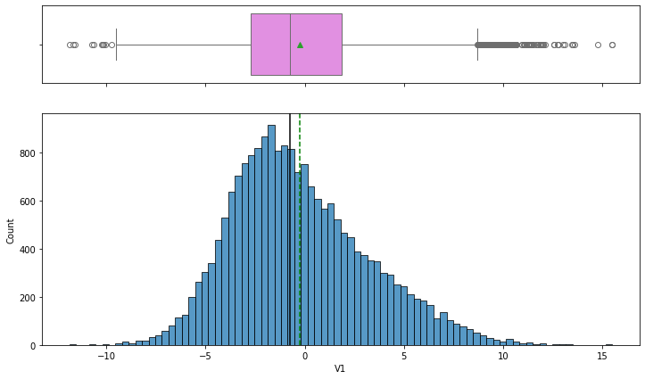

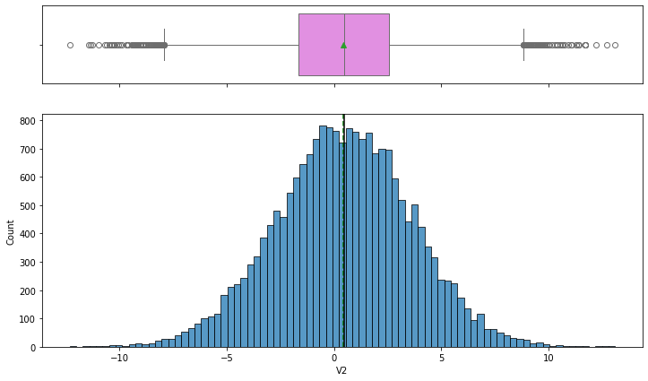

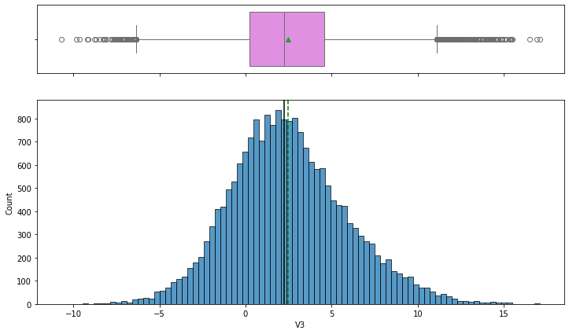

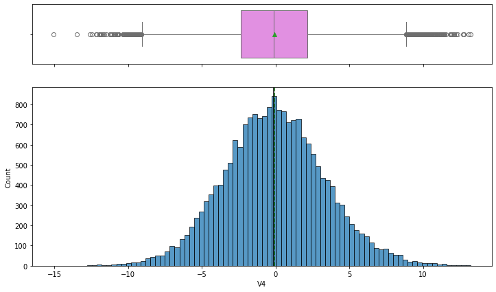

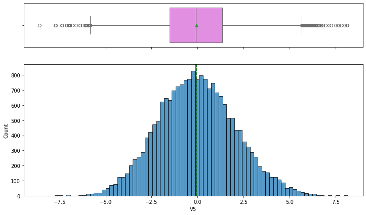

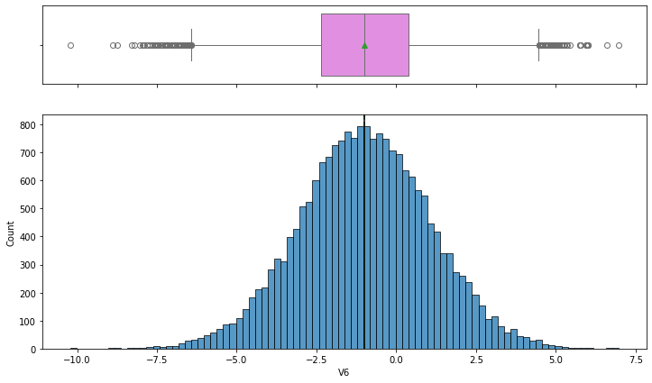

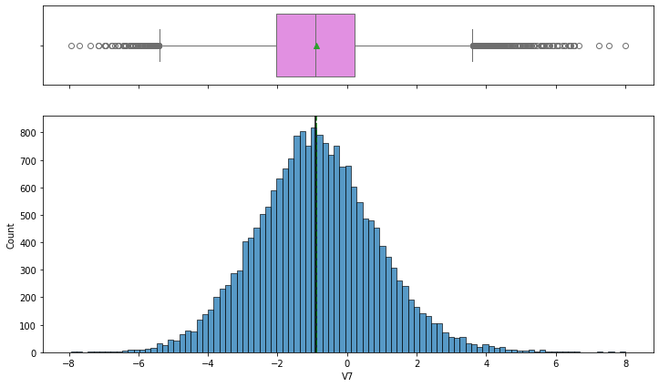

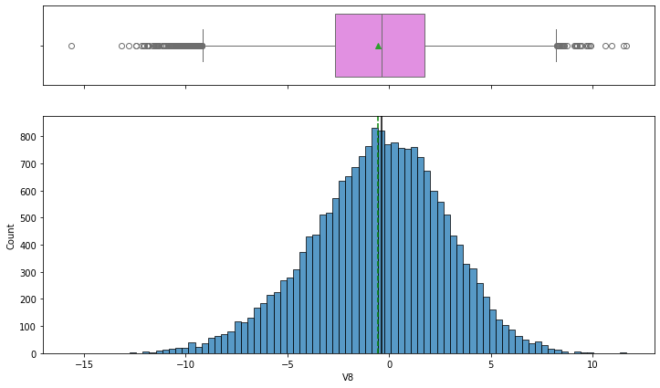

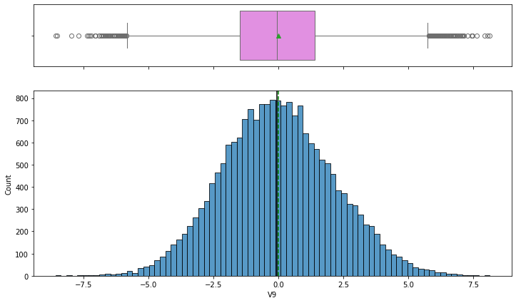

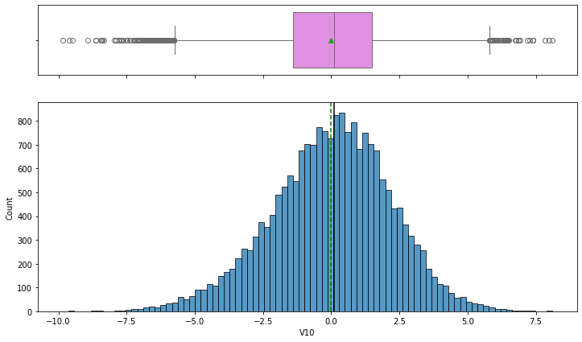

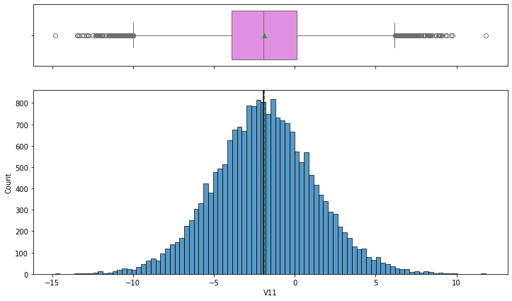

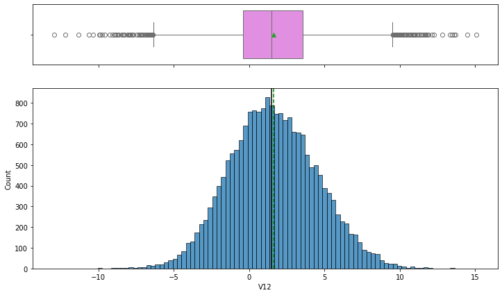

[29 more figures not shown]

```python
## Creating histogram and boxplots of all the variables
for feature in df.columns:
    histogram_boxplot(data, feature, figsize=(12, 7), kde=False, bins=None)
```

Most variables have normal distributed data. Most variables have outliers in the data. Variables have varying median and mean values.

#### Correlation

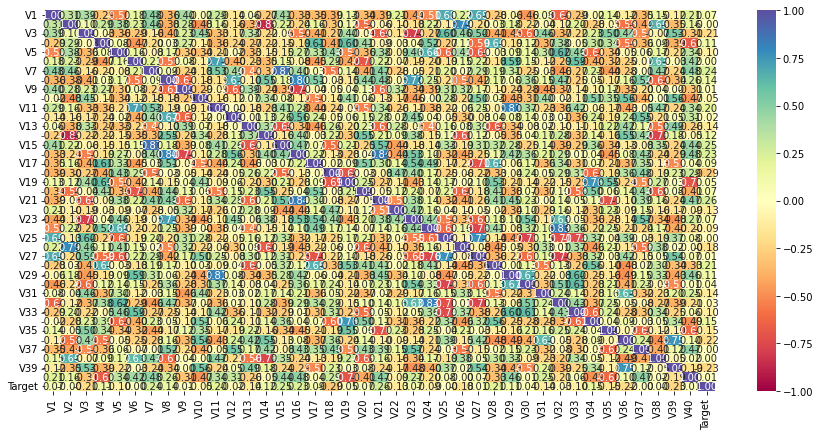

```python
# Correlation analysis for all variables
cols_list = df.select_dtypes(include=np.number).columns.tolist()


plt.figure(figsize=(15, 7))
sns.heatmap(
    df[cols_list].corr(), annot=True, vmin=-1, vmax=1, fmt=".2f", cmap="Spectral"
)
plt.show()
```

Generally the correlation between variables and the target variable is low as inidicated by color schemme about 0.00 and the low correlation values

### Target variable

```python
data["Target"].value_counts() ##  Complete the code to check the class distribution in target variable for train data
```

```
0    18890
1     1110
Name: Target, dtype: int64
```

The training data is imbalanced with the majority being No failure

```python
data_test["Target"].value_counts() ##  Complete the code to check the class distribution in target variable for test data
```

```
0    4718
1     282
Name: Target, dtype: int64
```

The test data is imbalanced with the majority being No failure

```python
# function to create labeled barplots


def labeled_barplot(data, feature, perc=False, n=None):
    """
    Barplot with percentage at the top

    data: dataframe
    feature: dataframe column
    perc: whether to display percentages instead of count (default is False)
    n: displays the top n category levels (default is None, i.e., display all levels)
    """

    total = len(data[feature])  # length of the column
    count = data[feature].nunique()
    if n is None:
        plt.figure(figsize=(count + 2, 6))
    else:
        plt.figure(figsize=(n + 2, 6))

    plt.xticks(rotation=90, fontsize=15)
    ax = sns.countplot(
        data=data,
        x=feature,
        palette="Paired",
        order=data[feature].value_counts().index[:n],
    )

    for p in ax.patches:
        if perc == True:
            label = "{:.1f}%".format(
                100 * p.get_height() / total
            )  # percentage of each class of the category
        else:
            label = p.get_height()  # count of each level of the category

        x = p.get_x() + p.get_width() / 2  # width of the plot
        y = p.get_height()  # height of the plot

        ax.annotate(
            label,
            (x, y),
            ha="center",
            va="center",
            size=12,
            xytext=(0, 5),
            textcoords="offset points",
        )  # annotate the percentage

    plt.show()  # show the plot
```

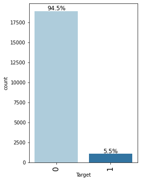

```python
# Creating barplots for target variable on training data
labeled_barplot(data, "Target", perc=True)
```

The failure data in the dataframe for train data is about 5.5% while the no failure data comprise 94.5%

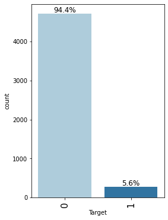

```python
# Creating barplots for target variable of testing data
labeled_barplot(data_test, "Target", perc=True)
```

Data is imbalanced. The failure data in the dataframe for test data is about 5.6% while the no failure data comprise 94.4%

## Data Pre-Processing

```python
# Dividing train data into X and y
X = data.drop(["Target"], axis=1)
y = data["Target"]
```

The data is divided into dependent and dependent variables.

```python
# Splitting train dataset into training and validation set in the ratio 75:25

X_train, X_val, y_train, y_val = train_test_split(X, y, test_size=0.25, random_state=1, stratify=y)
```

The training data is split into train and validation sets

```python
# Checking the number of rows and columns in the X_train data

X_train.shape

# Checking the number of rows and columns in the X_val data
X_val.shape

print(X_train.shape, X_val.shape)
```

```
(15000, 40) (5000, 40)
```

The shape of train and validation set dataframe is 15000 rows for train data and 5000 rows as validation set

```python
# Dividing test data into X_test and y_test (Code to drop target variable from test data and tore target variable in y_test)


X_test = data_test.drop(["Target"], axis=1)
y_test = data_test["Target"]
```

```python
# Checking the number of rows and columns in the X_test data
X_test.shape ##  Complete the code to view dimensions of the X_test data
```

```
(5000, 40)
```

The dataset structure of the test dataset is 5000 rows and 40 columns

## Missing value imputation

```python
# creating an instace of the imputer to be used
imputer = SimpleImputer(strategy="median")
```

Missing data will be imputed by median

```python
# Code to fit and transform the train data
X_train = pd.DataFrame(imputer.fit_transform(X_train), columns=X_train.columns)

# Code to transform the validation data
X_val = pd.DataFrame(imputer.transform(X_val), columns=X_train.columns)

# Code to transform the test data
X_test = pd.DataFrame(imputer.transform(X_test), columns=X_train.columns) ## Complete the code to impute missing values in X_test without data leakage
```

The train, validation and test data sets have been fitted and transformed by imputer (median). Missing values in X_val have been imputed without data leakage

```python
# Checking that no column has missing values in train or test sets
print(X_train.isna().sum())
print("-" * 30)

X_val.isna().sum() ## Complete the code to check the count of missing values in validation set
X_test.isna().sum() ## Complete the code to check the count of missing values in test set
```

```
V1     0
V2     0
V3     0
V4     0
V5     0
V6     0
V7     0
V8     0
V9     0
V10    0
V11    0
V12    0
V13    0
V14    0
V15    0
V16    0
V17    0
V18    0
V19    0
V20    0
V21    0
V22    0
V23    0
V24    0
V25    0
V26    0
V27    0
V28    0
V29    0
V30    0
V31    0
V32    0
V33    0
V34    0
V35    0
V36    0
V37    0
V38    0
V39    0
V40    0
dtype: int64
------------------------------
```

```
V1     0
V2     0
V3     0
V4     0
V5     0
V6     0
V7     0
V8     0
V9     0
V10    0
V11    0
V12    0
V13    0
V14    0
V15    0
V16    0
V17    0
V18    0
V19    0
V20    0
V21    0
V22    0
V23    0
V24    0
V25    0
V26    0
V27    0
V28    0
V29    0
V30    0
V31    0
V32    0
V33    0
V34    0
V35    0
V36    0
V37    0
V38    0
V39    0
V40    0
dtype: int64
```

No column has missing values in train or test sets after imputation

## Model Building

### Model evaluation criterion

The nature of predictions made by the classification model will translate as follows:

- True positives (TP) are failures correctly predicted by the model.
- False negatives (FN) are real failures in a generator where there is no detection by model.
- False positives (FP) are failure detections in a generator where there is no failure.
- The best metric will ensure that the maximum number of generator failures are predicted correctly by the model.
- We focus on Recall, as greater the Recall, the higher the chances of minimizing false negatives.
- We minimize false negatives because if a model predicts that a machine will have no failure when there will be a failure, it will increase the maintenance cost.

#### Function to output different metrics (including recall) on the train and test set and confusion matrix

```python
# defining a function to compute different metrics to check performance of a classification model built using sklearn
def model_performance_classification_sklearn(model, predictors, target):
    """
    Function to compute different metrics to check classification model performance

    model: classifier
    predictors: independent variables
    target: dependent variable
    """

    # predicting using the independent variables
    pred = model.predict(predictors)

    acc = accuracy_score(target, pred)  # to compute Accuracy
    recall = recall_score(target, pred)  # to compute Recall
    precision = precision_score(target, pred)  # to compute Precision
    f1 = f1_score(target, pred)  # to compute F1-score

    # creating a dataframe of metrics
    df_perf = pd.DataFrame(
        {
            "Accuracy": acc,
            "Recall": recall,
            "Precision": precision,
            "F1": f1
        },
        index=[0],
    )

    return df_perf
```

### Defining scorer to be used for cross-validation and hyperparameter tuning

- We want to reduce false negatives and will try to maximize "Recall".
- To maximize Recall, we can use Recall as a **scorer** in cross-validation and hyperparameter tuning.

```python
# Type of scoring used to compare parameter combinations
scorer = metrics.make_scorer(metrics.recall_score)
```

### Model Building on original data

```python
models = []  # Empty list to store all the models

# Appending models into the list
models.append(("Logistic regression", LogisticRegression(random_state=1)))
models.append(("Bagging", BaggingClassifier(random_state=1)))
models.append(("DecisionTreeClassifier", DecisionTreeClassifier(random_state=1)))
models.append(("AdaBoost", AdaBoostClassifier(random_state=1)))
models.append(("GradientBoost", GradientBoostingClassifier(random_state=1)))
models.append(("RandomForest", RandomForestClassifier(random_state=1)))

# Empty list to store all model's CV scores and empty list to store name of the models
results1 = []
names = []


# loop through all models to get the mean cross validated score
print("\n" "Cross-Validation performance on training dataset:" "\n")

# Setting number of splits equal to 5
for name, model in models:
    kfold = StratifiedKFold(
        n_splits=5, shuffle=True, random_state=1
    )

    cv_result = cross_val_score(
        estimator=model, X=X_train, y=y_train, scoring=scorer, cv=kfold
    )
    results1.append(cv_result)
    names.append(name)
    print("{}: {}".format(name, cv_result.mean()))

print("\n" "Validation Performance:" "\n")

for name, model in models:
    model.fit(X_train, y_train)
    scores = recall_score(y_val, model.predict(X_val))
    print("{}: {}".format(name, scores))
```

```
Cross-Validation performance on training dataset:

Logistic regression: 0.4927566553639709
Bagging: 0.7210807301060529
DecisionTreeClassifier: 0.6982829521679532
AdaBoost: 0.6309140754635308
GradientBoost: 0.7066661857008874
RandomForest: 0.7235192266070268

Validation Performance:

Logistic regression: 0.48201438848920863
Bagging: 0.7302158273381295
DecisionTreeClassifier: 0.7050359712230215
AdaBoost: 0.6762589928057554
GradientBoost: 0.7230215827338129
RandomForest: 0.7266187050359713
```

The model with the best recall on original training data set is Random forest (72.3%) followed by the Bagging classifier (72.1%) and GradientBoost classifier (70.6%). The least recall was by the Logistic Regression model (49%) followed by AdaBoost (63.1%). On the validation data set the best recall was returned by the Bagging classifier (73.02%) and RandomForest (72.6%).

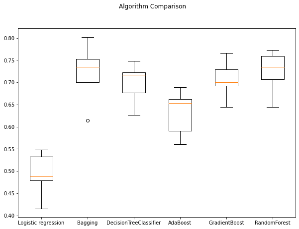

```python
# Plotting boxplots for CV scores of all models defined above
fig = plt.figure(figsize=(10, 7))

fig.suptitle("Algorithm Comparison")
ax = fig.add_subplot(111)

plt.boxplot(results1)
ax.set_xticklabels(names)

plt.show()
```

### Model Building with oversampled data

```python
print("Before OverSampling, counts of label '1': {}".format(sum(y_train == 1)))
print("Before OverSampling, counts of label '0': {} \n".format(sum(y_train == 0)))

# Synthetic Minority Over Sampling Technique
sm = SMOTE(sampling_strategy=1, k_neighbors=5, random_state=1)
X_train_over, y_train_over = sm.fit_resample(X_train, y_train)


print("After OverSampling, counts of label '1': {}".format(sum(y_train_over == 1)))
print("After OverSampling, counts of label '0': {} \n".format(sum(y_train_over == 0)))


print("After OverSampling, the shape of train_X: {}".format(X_train_over.shape))
print("After OverSampling, the shape of train_y: {} \n".format(y_train_over.shape))
```

```
Before OverSampling, counts of label '1': 832
Before OverSampling, counts of label '0': 14168

After OverSampling, counts of label '1': 14168
After OverSampling, counts of label '0': 14168

After OverSampling, the shape of train_X: (28336, 40)
After OverSampling, the shape of train_y: (28336,)
```

The training data set counts before and after oversampling using SMOTE strategy

```python
models = []  # Empty list to store all the models

# Appending models into the list
models.append(("Logistic regression", LogisticRegression(random_state=1)))
models.append(("Bagging", BaggingClassifier(random_state=1)))
models.append(("DecisionTreeClassifier", DecisionTreeClassifier(random_state=1)))
models.append(("AdaBoost", AdaBoostClassifier(random_state=1)))
models.append(("GradientBoost", GradientBoostingClassifier(random_state=1)))
models.append(("RandomForest", RandomForestClassifier(random_state=1)))

results1 = []  # Empty list to store all model's CV scores
names = []  # Empty list to store name of the models


# loop through all models to get the mean cross validated score
print("\n" "Cross-Validation performance on training dataset:" "\n")

for name, model in models:
    kfold = StratifiedKFold(
        n_splits=5, shuffle=True, random_state=1
    )  # Setting number of splits equal to 5
    cv_result = cross_val_score(
        estimator=model, X=X_val, y=y_val, scoring=scorer, cv=kfold
    )  ## Complete the code to build models on oversampled data
    results1.append(cv_result)
    names.append(name)
    print("{}: {}".format(name, cv_result.mean()))

print("\n" "Validation Performance:" "\n")

for name, model in models:
    model.fit(X_val,y_val)## Complete the code to build models on oversampled data
    scores = recall_score(y_val, model.predict(X_val))
    print("{}: {}".format(name, scores))
```

```
Cross-Validation performance on training dataset:

Logistic regression: 0.4855194805194805
Bagging: 0.6042207792207792
DecisionTreeClassifier: 0.6407142857142857
AdaBoost: 0.5754545454545454
GradientBoost: 0.6513636363636364
RandomForest: 0.5934415584415584

Validation Performance:

Logistic regression: 0.5035971223021583
Bagging: 0.9460431654676259
DecisionTreeClassifier: 1.0
AdaBoost: 0.7266187050359713
GradientBoost: 0.8741007194244604
RandomForest: 1.0
```

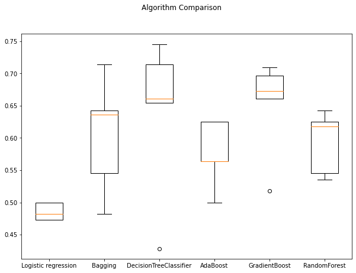

```python
# Plotting boxplots for CV scores to check model performance on oversampled data of all models defined above

# Plotting boxplots for CV scores of all models defined above
fig = plt.figure(figsize=(10, 7))

fig.suptitle("Algorithm Comparison")
ax = fig.add_subplot(111)

plt.boxplot(results1)
ax.set_xticklabels(names)

plt.show()
```

### Model Building with undersampled data

```python
rus = RandomUnderSampler(random_state=1, sampling_strategy=1)
X_train_un, y_train_un = rus.fit_resample(X_train, y_train)


print("Before UnderSampling, counts of label '1': {}".format(sum(y_train == 1)))
print("Before UnderSampling, counts of label '0': {} \n".format(sum(y_train == 0)))


print("After UnderSampling, counts of label '1': {}".format(sum(y_train_un == 1)))
print("After UnderSampling, counts of label '0': {} \n".format(sum(y_train_un == 0)))


print("After UnderSampling, the shape of train_X: {}".format(X_train_un.shape))
print("After UnderSampling, the shape of train_y: {} \n".format(y_train_un.shape))
```

```
Before UnderSampling, counts of label '1': 832
Before UnderSampling, counts of label '0': 14168

After UnderSampling, counts of label '1': 832
After UnderSampling, counts of label '0': 832

After UnderSampling, the shape of train_X: (1664, 40)
After UnderSampling, the shape of train_y: (1664,)
```

Counts for undersampled training data

```python
models = []  # Empty list to store all the models

# Appending models into the list
models.append(("Logistic regression", LogisticRegression(random_state=1)))
models.append(("Bagging", BaggingClassifier(random_state=1)))
models.append(("DecisionTreeClassifier", DecisionTreeClassifier(random_state=1)))
models.append(("AdaBoost", AdaBoostClassifier(random_state=1)))
models.append(("GradientBoost", GradientBoostingClassifier(random_state=1)))
models.append(("RandomForest", RandomForestClassifier(random_state=1)))

#list to store all model's CV scores
results1 = []

# list to store name of the models
names = []


# loop through all models to get the mean cross validated score
print("\n" "Cross-Validation performance on training dataset:" "\n")

# Setting number of splits equal to 5
for name, model in models:
    kfold = StratifiedKFold(
        n_splits=5, shuffle=True, random_state=1
    )

    cv_result = cross_val_score(
        estimator=model, X=X_val, y=y_val, scoring=scorer, cv=kfold
    )

## Code to build models on undersampled data
    results1.append(cv_result)
    names.append(name)
    print("{}: {}".format(name, cv_result.mean()))

print("\n" "Validation Performance:" "\n")

#Code to build models on undersampled data
for name, model in models:
    model.fit(X_val,y_val)
    scores = recall_score(y_val, model.predict(X_val))
    print("{}: {}".format(name, scores))
```

```
Cross-Validation performance on training dataset:

Logistic regression: 0.4855194805194805
Bagging: 0.6042207792207792
DecisionTreeClassifier: 0.6407142857142857
AdaBoost: 0.5754545454545454
GradientBoost: 0.6513636363636364
RandomForest: 0.5934415584415584

Validation Performance:

Logistic regression: 0.5035971223021583
Bagging: 0.9460431654676259
DecisionTreeClassifier: 1.0
AdaBoost: 0.7266187050359713
GradientBoost: 0.8741007194244604
RandomForest: 1.0
```

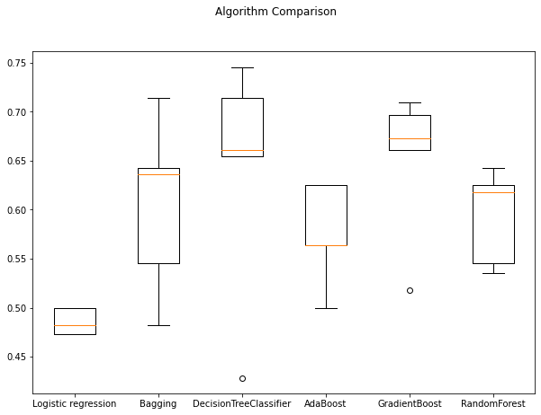

```python
# Plotting boxplots for CV scores of all models defined above to check model performance on undersampled data

# Plotting boxplots for CV scores of all models defined above
fig = plt.figure(figsize=(10, 7))

fig.suptitle("Algorithm Comparison")
ax = fig.add_subplot(111)

plt.boxplot(results1)
ax.set_xticklabels(names)

plt.show()
```

## Hyperparameter Tuning

### Tuning method for Bagging Classifier with oversampled data

```python
# defining model
Model = BaggingClassifier(random_state=1)

# Parameter grid to pass in RandomSearchCV
param_grid = {'max_samples': [0.8,0.9,1],
              'max_features': [0.7,0.8,0.9],
              'n_estimators': [30,50,70] }

#Calling RandomizedSearchCV
randomized_cv = RandomizedSearchCV(estimator=Model, param_distributions=param_grid, n_iter=10, n_jobs = -1, scoring=scorer, cv=5, random_state=1)

#Fitting parameters in RandomizedSearchCV
randomized_cv.fit(X_train_over,y_train_over)

print("Best parameters are {} with CV score={}:" .format(randomized_cv.best_params_,randomized_cv.best_score_))
```

```
Best parameters are {'n_estimators': 70, 'max_samples': 0.9, 'max_features': 0.8} with CV score=0.9828488269988673:
```

The best metrics for tuning the Bagging classifier on oversampled data are n_estimators = 70, max_samples = 0.9 and max_features = 0.8

```python
## Code with the best parameters obtained from tuning

tuned_Bgc1 = BaggingClassifier(
        n_estimators = 70, max_samples = 0.9, max_features = 0.8
)

## Code to fit the model on oversampled data
tuned_Bgc1.fit(X_train_over,y_train_over)
```

```
BaggingClassifier(max_features=0.8, max_samples=0.9, n_estimators=70)
```

```python
# checking perfromance on train data
Bgc1_train_perf = model_performance_classification_sklearn(tuned_Bgc1, X_train_over, y_train_over)
Bgc1_train_perf
```

|  | Accuracy | Recall | Precision | F1 |
| --- | --- | --- | --- | --- |
| 0 | 1.000 | 1.000 | 1.000 | 1.000 |

The recall score is 100%. The model is able to predict true poositives, false positives and false negatives precisely on oversampled train data

```python
# checking perfromance on validation set
Bgc1_val_perf = model_performance_classification_sklearn(tuned_Bgc1, X_val, y_val) ## Complete the code to check the performance on validation set
Bgc1_val_perf
```

|  | Accuracy | Recall | Precision | F1 |
| --- | --- | --- | --- | --- |
| 0 | 0.986 | 0.874 | 0.874 | 0.874 |

### Tuning method for Bagging Classifier with under-sampled data

```python
# defining model
Model = BaggingClassifier(random_state=1)

# Parameter grid to pass in RandomSearchCV
param_grid = {'max_samples': [0.8,0.9,1],
              'max_features': [0.7,0.8,0.9],
              'n_estimators': [30,50,70] }

#Calling RandomizedSearchCV
randomized_cv = RandomizedSearchCV(estimator=Model, param_distributions=param_grid, n_iter=10, n_jobs = -1, scoring=scorer, cv=5, random_state=1)

#Fitting parameters in RandomizedSearchCV
randomized_cv.fit(X_train_un,y_train_un)

print("Best parameters are {} with CV score={}:" .format(randomized_cv.best_params_,randomized_cv.best_score_))
```

```
Best parameters are {'n_estimators': 70, 'max_samples': 0.9, 'max_features': 0.9} with CV score=0.8966236202294207:
```

The best parametrs for tuning the Bagging Classifier on undersampled data are n_estimators = 70, max_samples = 0.9, max_features = 0.9

```python
## Code with the best parameters obtained from tuning

tuned_Bgc2 = BaggingClassifier(
    n_estimators = 70, max_samples = 0.9, max_features = 0.9
)

## Code to fit the model on undersampled data
tuned_Bgc2.fit(X_train_un,y_train_un)
```

```
BaggingClassifier(max_features=0.9, max_samples=0.9, n_estimators=70)
```

```python
# checking perfromance on train data
Bgc2_train_perf = model_performance_classification_sklearn(tuned_Bgc2, X_train_un, y_train_un)
Bgc2_train_perf
```

|  | Accuracy | Recall | Precision | F1 |
| --- | --- | --- | --- | --- |
| 0 | 1.000 | 1.000 | 1.000 | 1.000 |

Using undersampled data, the recall score is 100% on training set

```python
# checking perfromance on validation set
Bgc2_val_perf = model_performance_classification_sklearn(tuned_Bgc2, X_val, y_val)
Bgc2_val_perf
```

|  | Accuracy | Recall | Precision | F1 |
| --- | --- | --- | --- | --- |
| 0 | 0.935 | 0.896 | 0.457 | 0.605 |

The recall score drops to 89.6% on validation set of undersampled data

#### method for tuning Bagging Classifier with original data

```python
# defining model
Model = BaggingClassifier(random_state=1)

# Parameter grid to pass in RandomSearchCV
param_grid = {'max_samples': [0.8,0.9,1],
              'max_features': [0.7,0.8,0.9],
              'n_estimators': [30,50,70] }

#Calling RandomizedSearchCV
randomized_cv = RandomizedSearchCV(estimator=Model, param_distributions=param_grid, n_iter=10, n_jobs = -1, scoring=scorer, cv=5, random_state=1)

#Fitting parameters in RandomizedSearchCV
randomized_cv.fit(X_train,y_train)

print("Best parameters are {} with CV score={}:" .format(randomized_cv.best_params_,randomized_cv.best_score_))
```

```
Best parameters are {'n_estimators': 70, 'max_samples': 0.8, 'max_features': 0.9} with CV score=0.7308563595700166:
```

The best parameters for tuning the Bagging classifier on original data are n_estimators =70 , max_samples =0.8 , and max_features = 0.9

```python
## Code with the best parameters obtained from tuning

tuned_Bgc3 = BaggingClassifier(
    n_estimators = 70, max_samples = 0.8, max_features = 0.9
)

## Code to fit the model on original data
tuned_Bgc3.fit(X_train,y_train)
```

```
BaggingClassifier(max_features=0.9, max_samples=0.8, n_estimators=70)
```

```python
# checking perfromance on train data
Bgc3_train_perf = model_performance_classification_sklearn(tuned_Bgc3, X_train, y_train)
Bgc3_train_perf
```

|  | Accuracy | Recall | Precision | F1 |
| --- | --- | --- | --- | --- |
| 0 | 0.998 | 0.972 | 1.000 | 0.986 |

The recall score on train set of original data is 97.2%

```python
# checking perfromance on validation set
Bgc3_val_perf = model_performance_classification_sklearn(tuned_Bgc3, X_val, y_val)
Bgc3_val_perf
```

|  | Accuracy | Recall | Precision | F1 |
| --- | --- | --- | --- | --- |
| 0 | 0.984 | 0.741 | 0.963 | 0.837 |

The recall score on validation set of original data decreases to 74.1%

### Tuning method for Decision tree with oversampled data

```python
# defining model
Model = DecisionTreeClassifier(random_state=1)

# Parameter grid to pass in RandomSearchCV
param_grid = {'max_depth': np.arange(2,6),
              'min_samples_leaf': [1, 4, 7],
              'max_leaf_nodes' : [10,15],
              'min_impurity_decrease': [0.0001,0.001] }

#Calling RandomizedSearchCV
randomized_cv = RandomizedSearchCV(estimator=Model, param_distributions=param_grid, n_iter=10, n_jobs = -1, scoring=scorer, cv=5, random_state=1)

#Fitting parameters in RandomizedSearchCV
randomized_cv.fit(X_train_over,y_train_over)

print("Best parameters are {} with CV score={}:" .format(randomized_cv.best_params_,randomized_cv.best_score_))
```

```
Best parameters are {'min_samples_leaf': 7, 'min_impurity_decrease': 0.001, 'max_leaf_nodes': 15, 'max_depth': 3} with CV score=0.9102913265648006:
```

The best parameters for tuning DecisionTreeClassifier with oversampled data are min_samples_leaf= 7, min_impurity_decrease = 0.001, 'max_leaf_nodes'= 15, max_depth = 3

```python
## Code with the best parameters obtained from tuning

tuned_DT = DecisionTreeClassifier(
    min_samples_leaf= 7, min_impurity_decrease = 0.001, max_leaf_nodes = 15, max_depth = 3
)

## Code to fit the model on oversampled data
tuned_DT.fit(X_train_over,y_train_over)
```

```
DecisionTreeClassifier(max_depth=3, max_leaf_nodes=15,
                       min_impurity_decrease=0.001, min_samples_leaf=7)
```

```python
# checking perfromance on train data
DT_train_perf = model_performance_classification_sklearn(tuned_DT, X_train_over, y_train_over)
DT_train_perf
```

|  | Accuracy | Recall | Precision | F1 |
| --- | --- | --- | --- | --- |
| 0 | 0.843 | 0.917 | 0.799 | 0.854 |

Recall score is 91.7% on train set

```python
# checking perfromance on validation set
DT_val_perf = model_performance_classification_sklearn(tuned_DT, X_val, y_val) ## Complete the code to check the performance on validation set
DT_val_perf
```

|  | Accuracy | Recall | Precision | F1 |
| --- | --- | --- | --- | --- |
| 0 | 0.763 | 0.885 | 0.176 | 0.294 |

The recall score decreases to 88.5% on validation set

### tuning method for Decision tree with undersampled data

```python
# defining model
Model = DecisionTreeClassifier(random_state=1)

# Parameter grid to pass in RandomSearchCV
param_grid = {'max_depth': np.arange(2,20),
              'min_samples_leaf': [1, 2, 5, 7],
              'max_leaf_nodes' : [5, 10,15],
              'min_impurity_decrease': [0.0001,0.001] }

#Calling RandomizedSearchCV
randomized_cv = RandomizedSearchCV(estimator=Model, param_distributions=param_grid, n_iter=10, n_jobs = -1, scoring=scorer, cv=5, random_state=1)

#Fitting parameters in RandomizedSearchCV
randomized_cv.fit(X_train_un,y_train_un)

print("Best parameters are {} with CV score={}:" .format(randomized_cv.best_params_,randomized_cv.best_score_))
```

```
Best parameters are {'min_samples_leaf': 1, 'min_impurity_decrease': 0.001, 'max_leaf_nodes': 5, 'max_depth': 2} with CV score=0.850811629752543:
```

The best parameters for tuning are min_samples_leaf': 1, 'min_impurity_decrease': 0.001, 'max_leaf_nodes': 5, 'max_depth': 2

```python
## Code with the best parameters obtained from tuning

tuned_DT1 = DecisionTreeClassifier(
    min_samples_leaf= 1, min_impurity_decrease = 0.001, max_leaf_nodes = 5, max_depth = 2
)


## Code to fit the model on undersampled data
tuned_DT1.fit(X_train_un,y_train_un)
```

```
DecisionTreeClassifier(max_depth=2, max_leaf_nodes=5,
                       min_impurity_decrease=0.001)
```

```python
## Code to check the performance on train set
DT1_train_perf = model_performance_classification_sklearn(tuned_DT, X_train_un, y_train_un)
DT1_train_perf
```

|  | Accuracy | Recall | Precision | F1 |
| --- | --- | --- | --- | --- |
| 0 | 0.829 | 0.898 | 0.789 | 0.840 |

The recall score on train set is 89.8%

```python
## Code to check the performance on validation set
DT1_val_perf = model_performance_classification_sklearn(tuned_DT, X_val, y_val)
DT1_val_perf
```

|  | Accuracy | Recall | Precision | F1 |
| --- | --- | --- | --- | --- |
| 0 | 0.763 | 0.885 | 0.176 | 0.294 |

The recall score on validation set is 88.5% and not too different from the train set

### Sample tuning method for Decision tree with original data

```python
# defining model
Model = DecisionTreeClassifier(random_state=1)

# Parameter grid to pass in RandomSearchCV
param_grid = {'max_depth': np.arange(2,6),
              'min_samples_leaf': [1, 4, 7],
              'max_leaf_nodes' : [10,15],
              'min_impurity_decrease': [0.0001,0.001] }

#Calling RandomizedSearchCV
randomized_cv = RandomizedSearchCV(estimator=Model, param_distributions=param_grid, n_iter=10, n_jobs = -1, scoring=scorer, cv=5, random_state=1)

#Fitting parameters in RandomizedSearchCV
randomized_cv.fit(X_train,y_train)

print("Best parameters are {} with CV score={}:" .format(randomized_cv.best_params_,randomized_cv.best_score_))
```

```
Best parameters are {'min_samples_leaf': 7, 'min_impurity_decrease': 0.0001, 'max_leaf_nodes': 15, 'max_depth': 5} with CV score=0.5684366207344347:
```

The best parameters for tuning the model with original data are min_samples_leaf= 7, min_impurity_decrease = 0.0001, max_leaf_nodes= 15, max_depth = 5}

```python
## Code with the best parameters obtained from tuning

tuned_DT2 = DecisionTreeClassifier(
    min_samples_leaf= 7, min_impurity_decrease = 0.001, max_leaf_nodes = 15, max_depth = 5
)


## Code to fit the model on undersampled data
tuned_DT2.fit(X_train,y_train)
```

```
DecisionTreeClassifier(max_depth=5, max_leaf_nodes=15,
                       min_impurity_decrease=0.001, min_samples_leaf=7)
```

```python
DT2_train_perf = model_performance_classification_sklearn(tuned_DT, X_train, y_train)
DT2_train_perf
```

|  | Accuracy | Recall | Precision | F1 |
| --- | --- | --- | --- | --- |
| 0 | 0.776 | 0.898 | 0.186 | 0.308 |

The recall is 89.8% on train set

```python
DT2_val_perf = model_performance_classification_sklearn(tuned_DT, X_val, y_val) ## Complete the code to check the performance on validation set
DT2_val_perf
```

|  | Accuracy | Recall | Precision | F1 |
| --- | --- | --- | --- | --- |
| 0 | 0.763 | 0.885 | 0.176 | 0.294 |

The recall on vallidation set is 88.5% and not to different from the train set

### Tuning AdaBoost using oversampled data

```python
%%time

# defining model
Model = AdaBoostClassifier(random_state=1)

# Parameter grid to pass in RandomSearchCV
param_grid = {
    "n_estimators": [100, 150, 200],
    "learning_rate": [0.2, 0.05],
    "base_estimator": [DecisionTreeClassifier(max_depth=1, random_state=1), DecisionTreeClassifier(max_depth=2, random_state=1), DecisionTreeClassifier(max_depth=3, random_state=1),
    ]
}

#Calling RandomizedSearchCV
randomized_cv = RandomizedSearchCV(estimator=Model, param_distributions=param_grid, n_iter=50, n_jobs = -1, scoring=scorer, cv=5, random_state=1)

#Fitting parameters in RandomizedSearchCV (Code to fit the model on over sampled data)
randomized_cv.fit(X_train_over,y_train_over)

print("Best parameters are {} with CV score={}:" .format(randomized_cv.best_params_,randomized_cv.best_score_))
```

```
Best parameters are {'n_estimators': 200, 'learning_rate': 0.2, 'base_estimator': DecisionTreeClassifier(max_depth=3, random_state=1)} with CV score=0.971555946263926:
Wall time: 28min 6s
```

The best parameters for tuning the model are n_estimators= 200, learning_rate= 0.2, base_estimator= DecisionTreeClassifier(max_depth=3, random_state=1)

These are the identified parametrs best fit for tuning the AdaBoost model using oversampled data

```python
## Code with the best parameters obtained from tuning

tuned_ada = AdaBoostClassifier(
    n_estimators= 200, learning_rate= 0.2, base_estimator= DecisionTreeClassifier(max_depth=3, random_state=1)
)

## Code to fit the model on oversampled data
tuned_ada.fit(X_train_over,y_train_over)
```

```
AdaBoostClassifier(base_estimator=DecisionTreeClassifier(max_depth=3,
                                                         random_state=1),
                   learning_rate=0.2, n_estimators=200)
```

The best parameters obtained from tuning AdaBoostClassifier

```python
ada_train_perf = model_performance_classification_sklearn(tuned_ada, X_train_over, y_train_over)
ada_train_perf
```

|  | Accuracy | Recall | Precision | F1 |
| --- | --- | --- | --- | --- |
| 0 | 0.992 | 0.988 | 0.995 | 0.992 |

The tuned AdaBoostCLassifier recall score on oversampled training data is 98.8%

```python
ada_val_perf = model_performance_classification_sklearn(tuned_ada, X_val, y_val) ## Complete the code to check the performance on validation set
ada_val_perf
```

|  | Accuracy | Recall | Precision | F1 |
| --- | --- | --- | --- | --- |
| 0 | 0.979 | 0.853 | 0.790 | 0.820 |

### Tuning Random forest using undersampled data

```python
%%time

# defining model
Model = RandomForestClassifier(random_state=1)

# Parameter grid to pass in RandomSearchCV
param_grid = {
    "n_estimators": [200,250,300],
    "min_samples_leaf": np.arange(1, 4),
    "max_features": [np.arange(0.3, 0.6, 0.1),'sqrt'],
    "max_samples": np.arange(0.4, 0.7, 0.1)}


#Calling RandomizedSearchCV
randomized_cv = RandomizedSearchCV(estimator=Model, param_distributions=param_grid, n_iter=50, n_jobs = -1, scoring=scorer, cv=5, random_state=1)

#Fitting parameters in RandomizedSearchCV
randomized_cv.fit(X_train_un,y_train_un) ## Complete the code to fit the model on under sampled data

print("Best parameters are {} with CV score={}:" .format(randomized_cv.best_params_,randomized_cv.best_score_))
```

```
Best parameters are {'n_estimators': 300, 'min_samples_leaf': 2, 'max_samples': 0.5, 'max_features': 'sqrt'} with CV score=0.8990116153235697:
Wall time: 49.7 s
```

These are the best model parameters identified by ramdomisedSearchCV for tuning the RandomForestClassifier using undersampled data

```python
# Creating new pipeline with best parameters
tuned_rf2 = RandomForestClassifier(
    max_features='sqrt',
    random_state=1,
    max_samples=0.5,
    n_estimators=300,
    min_samples_leaf=2,
)

## Code to fit the model on under sampled data
tuned_rf2.fit(X_train_un,y_train_un)
```

```
RandomForestClassifier(max_samples=0.5, min_samples_leaf=2, n_estimators=300,
                       random_state=1)
```

These are the best parameters obtained from tuning RandomForestClassfier using under sampled data

```python
## Code to check the performance on undersampled train set
rf2_train_perf = model_performance_classification_sklearn(tuned_rf2, X_train_un, y_train_un)
rf2_train_perf
```

|  | Accuracy | Recall | Precision | F1 |
| --- | --- | --- | --- | --- |
| 0 | 0.961 | 0.933 | 0.989 | 0.960 |

The recall score on train undersampled data is 93.3%

```python
## Code to check the performance on validation set
rf2_val_perf = model_performance_classification_sklearn(tuned_rf2, X_val, y_val)
rf2_val_perf
```

|  | Accuracy | Recall | Precision | F1 |
| --- | --- | --- | --- | --- |
| 0 | 0.938 | 0.885 | 0.468 | 0.612 |

The recall score on tuned validation set of under-sampled data is 88.5% which is lower than the 93.3%

### Tuning Gradient Boosting using oversampled data

```python
%%time

# defining model
Model = GradientBoostingClassifier(random_state=1)

#Parameter grid to pass in RandomSearchCV
param_grid={"n_estimators": np.arange(100,150,25), "learning_rate": [0.2, 0.05, 1], "subsample":[0.5,0.7], "max_features":[0.5,0.7]}

#Calling RandomizedSearchCV
randomized_cv = RandomizedSearchCV(estimator=Model, param_distributions=param_grid, scoring=scorer, n_iter=50, n_jobs = -1, cv=5, random_state=1)

#Fitting parameters in RandomizedSearchCV
randomized_cv.fit(X_train_over, y_train_over)

print("Best parameters are {} with CV score={}:" .format(randomized_cv.best_params_,randomized_cv.best_score_))
```

```
Best parameters are {'subsample': 0.7, 'n_estimators': 125, 'max_features': 0.5, 'learning_rate': 1} with CV score=0.9736732944545844:
Wall time: 12min 12s
```

These are the best parameters for tuning GradientBoost model using oversampled data, subsample = 0.7, n_estimators = 125, max_features = 0.5 and learning_rate = 1

```python
# Creating new pipeline with best parameters
tuned_gbm = GradientBoostingClassifier(
    max_features=0.5,
    random_state=1,
    learning_rate=1,
    n_estimators=125,
    subsample=0.7

)
## Code with the best parameters obtained from tuning

tuned_gbm.fit(X_train_over, y_train_over)
```

```
GradientBoostingClassifier(learning_rate=1, max_features=0.5, n_estimators=125,
                           random_state=1, subsample=0.7)
```

```python
## Code to check the performance on oversampled train set
gbm_train_perf = model_performance_classification_sklearn(tuned_gbm, X_train_over, y_train_over)
gbm_train_perf
```

|  | Accuracy | Recall | Precision | F1 |
| --- | --- | --- | --- | --- |
| 0 | 0.993 | 0.992 | 0.994 | 0.993 |

The recall score on training set of over sampled data set using GradientBooast model is 99.2%

```python
gbm_val_perf = model_performance_classification_sklearn(tuned_gbm, X_val, y_val) ## Complete the code to check the performance on validation set
gbm_val_perf
```

|  | Accuracy | Recall | Precision | F1 |
| --- | --- | --- | --- | --- |
| 0 | 0.969 | 0.856 | 0.678 | 0.757 |

The recall score on validation data is slightly lower at 85.6%

### Tuning XGBoost using oversampled data

```python
%%time

# defining model
Model = XGBClassifier(random_state=1,eval_metric='logloss')

#Parameter grid to pass in RandomSearchCV
param_grid={'n_estimators':[150,200,250],'scale_pos_weight':[5,10], 'learning_rate':[0.1,0.2], 'gamma':[0,3,5], 'subsample':[0.8,0.9]}

#Calling RandomizedSearchCV
randomized_cv = RandomizedSearchCV(estimator=Model, param_distributions=param_grid, n_iter=50, n_jobs = -1, scoring=scorer, cv=5, random_state=1)

#Fitting parameters in RandomizedSearchCV
randomized_cv.fit(X_train_over, y_train_over) ## Complete the code to fit the model on over sampled data

print("Best parameters are {} with CV score={}:" .format(randomized_cv.best_params_,randomized_cv.best_score_))
```

```
Best parameters are {'subsample': 0.9, 'scale_pos_weight': 10, 'n_estimators': 150, 'learning_rate': 0.1, 'gamma': 0} with CV score=0.9960475154078072:
Wall time: 3min 16s
```

These are the best paramenters identifed by RandomisedSearchCV for tuning XGBClassifier for use on oversampled training data - subsample = 0.9, scale_pos_weight = 10, n_estimators =150, learning_rate = 0.1, gamma = 0

```python
xgb2 = XGBClassifier(
    random_state=1,
    eval_metric="logloss",
    subsample=0.9,
    scale_pos_weight=10,
    n_estimators=150,
    learning_rate=0.1,
    gamma=0
)## Complete the code with the best parameters obtained from tuning

xgb2.fit(X_train_over, y_train_over) ## Complete the code to fit the model on over sampled data
```

```
XGBClassifier(base_score=None, booster=None, callbacks=None,
              colsample_bylevel=None, colsample_bynode=None,
              colsample_bytree=None, device=None, early_stopping_rounds=None,
              enable_categorical=False, eval_metric='logloss',
              feature_types=None, gamma=0, grow_policy=None,
              importance_type=None, interaction_constraints=None,
              learning_rate=0.1, max_bin=None, max_cat_threshold=None,
              max_cat_to_onehot=None, max_delta_step=None, max_depth=None,
              max_leaves=None, min_child_weight=None, missing=nan,
              monotone_constraints=None, multi_strategy=None, n_estimators=150,
              n_jobs=None, num_parallel_tree=None, random_state=1, ...)
```

These are the model best parameters for XGB model for use on oversampled data

```python
xgb2_train_perf =  model_performance_classification_sklearn(xgb2, X_train_over, y_train_over) ## Complete the code to check the performance on oversampled train set
xgb2_train_perf
```

|  | Accuracy | Recall | Precision | F1 |
| --- | --- | --- | --- | --- |
| 0 | 0.994 | 1.000 | 0.988 | 0.994 |

The recall score on train data using the tuned XGB model is 100%

```python
## Code to check the performance on validation set
xgb2_val_perf =  model_performance_classification_sklearn(xgb2, X_val, y_val)
xgb2_val_perf
```

|  | Accuracy | Recall | Precision | F1 |
| --- | --- | --- | --- | --- |
| 0 | 0.967 | 0.892 | 0.648 | 0.750 |

The recall score on validation data set by the tuned XGB model is lower at 89.2% from 100%

## Model performance comparison and choosing the final model

```python
# code for training performance comparison

models_train_comp_df = pd.concat(
    [
        gbm_train_perf.T,
        ada_train_perf.T,
        rf2_train_perf.T,
        xgb2_train_perf.T,
        DT_train_perf.T,
        DT1_train_perf.T,
        DT2_train_perf.T,
        Bgc1_train_perf.T,
        Bgc2_train_perf.T,
        Bgc3_train_perf.T
    ],
    axis=1,
)
models_train_comp_df.columns = [
    "Gradient Boosting tuned with oversampled data",
    "AdaBoost classifier tuned with oversampled data",
    "Random forest tuned with undersampled data",
    "XGBoost tuned with oversampled data",
    "DecisionTreeClassifier tuned with oversampled data",
    "DecisionTreeClassifier tuned with undersampled data",
    "DecisionTreeClassifier tuned with original sample data",
    "BaggingClassifier tuned with oversampled data",
    "BaggingClassifier tuned with undersampled data",
    "BaggingClassifier tuned with original sample data"
]
print("Training performance comparison:")
models_train_comp_df
```

```
Training performance comparison:
```

|  | Gradient Boosting tuned with oversampled data | AdaBoost classifier tuned with oversampled data | Random forest tuned with undersampled data | XGBoost tuned with oversampled data | DecisionTreeClassifier tuned with oversampled data | DecisionTreeClassifier tuned with undersampled data | DecisionTreeClassifier tuned with original sample data | BaggingClassifier tuned with oversampled data | BaggingClassifier tuned with undersampled data | BaggingClassifier tuned with original sample data |
| --- | --- | --- | --- | --- | --- | --- | --- | --- | --- | --- |
| Accuracy | 0.993 | 0.992 | 0.961 | 0.994 | 0.843 | 0.829 | 0.776 | 1.000 | 1.000 | 0.998 |
| Recall | 0.992 | 0.988 | 0.933 | 1.000 | 0.917 | 0.898 | 0.898 | 1.000 | 1.000 | 0.972 |
| Precision | 0.994 | 0.995 | 0.989 | 0.988 | 0.799 | 0.789 | 0.186 | 1.000 | 1.000 | 1.000 |
| F1 | 0.993 | 0.992 | 0.960 | 0.994 | 0.854 | 0.840 | 0.308 | 1.000 | 1.000 | 0.986 |

Based on the provided training performance comparison, the XGBoost tuned with oversampled data, BaggingClassifier tuned with oversampled and undersampled data appear to be the best performing models on the train data. They achieve a perfect recall score of 1.000, meaning it correctly identifies all positive cases.

```python
# validation performance comparison

## code to compare the performance on validation set


models_val_comp_df = pd.concat(
    [
        gbm_val_perf.T,
        ada_val_perf.T,
        rf2_val_perf.T,
        xgb2_val_perf.T,
        DT_val_perf.T,
        DT1_val_perf.T,
        DT2_val_perf.T,
        Bgc1_val_perf.T,
        Bgc2_val_perf.T,
        Bgc3_val_perf.T,
    ],
    axis=1,
)
models_val_comp_df.columns = [
    "Gradient Boosting tuned with oversampled data",
    "AdaBoost classifier tuned with oversampled data",
    "Random forest tuned with undersampled data",
    "XGBoost tuned with oversampled data",
    "DecisionTreeClassifier tuned with oversampled data",
    "DecisionTreeClassifier tuned with undersampled data",
    "DecisionTreeClassifier tuned with original sample data",
    "BaggingClassifier tuned with oversampled data",
    "BaggingClassifier tuned with undersampled data",
    "BaggingClassifier tuned with original sample data"
]

print("Training performance comparison:")
models_val_comp_df
```

```
Training performance comparison:
```

|  | Gradient Boosting tuned with oversampled data | AdaBoost classifier tuned with oversampled data | Random forest tuned with undersampled data | XGBoost tuned with oversampled data | DecisionTreeClassifier tuned with oversampled data | DecisionTreeClassifier tuned with undersampled data | DecisionTreeClassifier tuned with original sample data | BaggingClassifier tuned with oversampled data | BaggingClassifier tuned with undersampled data | BaggingClassifier tuned with original sample data |
| --- | --- | --- | --- | --- | --- | --- | --- | --- | --- | --- |
| Accuracy | 0.969 | 0.979 | 0.938 | 0.967 | 0.763 | 0.763 | 0.763 | 0.986 | 0.935 | 0.984 |
| Recall | 0.856 | 0.853 | 0.885 | 0.892 | 0.885 | 0.885 | 0.885 | 0.874 | 0.896 | 0.741 |
| Precision | 0.678 | 0.790 | 0.468 | 0.648 | 0.176 | 0.176 | 0.176 | 0.874 | 0.457 | 0.963 |
| F1 | 0.757 | 0.820 | 0.612 | 0.750 | 0.294 | 0.294 | 0.294 | 0.874 | 0.605 | 0.837 |

Gradient Boosting tuned with oversampled data: Recall: 0.856. The recall score is moderate, indicating that this model correctly identifies a reasonable proportion of positive cases. However, there’s room for improvement. AdaBoost classifier tuned with oversampled data: Recall: 0.853. Similar to Gradient Boosting, AdaBoost also has a moderate recall score. It performs reasonably well but might miss some positive cases. Random forest tuned with undersampled data: Recall: 0.885, The recall is good, suggesting that this model identifies positive cases better than the previous two. However, it’s not perfect. XGBoost tuned with oversampled data: Recall: 0.892. XGBoost performs well in terms of recall, correctly identifying a high proportion of positive cases. It’s a strong contender. DecisionTreeClassifier tuned with oversampled data: Good recall: 0.885. DecisionTreeClassifier tuned with undersampled data: Good recall: 0.885.  
BaggingClassifier tuned with oversampled data: Recall: 0.874 Bagging achieves a decent recall score. It’s robust and performs consistently. BaggingClassifier tuned with undersampled data: Recall: 0.896. This model has a higher recall, indicating better performance in identifying positive cases. BaggingClassifier tuned with original sample data: Recall: 0.741. The recall is lower here, suggesting that this model might miss some positive cases.

```python
# Let's check the performance of best model on test set

xgb2_test_perf =  model_performance_classification_sklearn(xgb2, X_test, y_test)
xgb2_test_perf
```

|  | Accuracy | Recall | Precision | F1 |
| --- | --- | --- | --- | --- |
| 0 | 0.966 | 0.858 | 0.649 | 0.739 |

The recall score for tuned Xgb2 model on test data set is 85.8%

```python
# Let's check the performance of BaggingClassifier with undersample as the best model on test set

Bgc2_test_perf =  model_performance_classification_sklearn(tuned_Bgc2, X_test, y_test)
Bgc2_test_perf
```

|  | Accuracy | Recall | Precision | F1 |
| --- | --- | --- | --- | --- |
| 0 | 0.937 | 0.869 | 0.469 | 0.609 |

### Feature Importances

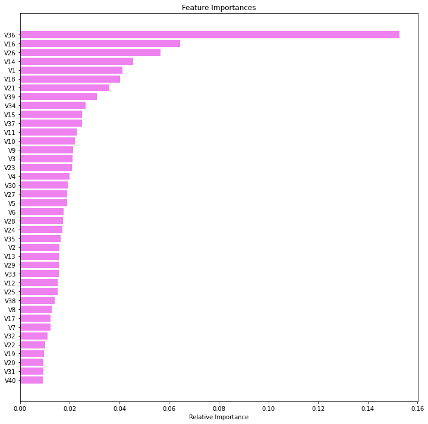

```python
feature_names = X_train.columns
importances =  xgb2.feature_importances_ ## Complete the code to check the feature importance of the best model
indices = np.argsort(importances)

plt.figure(figsize=(12, 12))
plt.title("Feature Importances")
plt.barh(range(len(indices)), importances[indices], color="violet", align="center")
plt.yticks(range(len(indices)), [feature_names[i] for i in indices])
plt.xlabel("Relative Importance")
plt.show()
```

The most 7 important features in order of improtance is V36, V16, V26, V14, V1, V18 and V21 and contribute significantly to the model for predicting failure

## Using Pipelines to build the final model

- Since we have only one datatype in the data, we don't need to use column transformer here

```python
## Complete the code to create pipeline for the best model
pipeline_model= Pipeline([
    ('scaler',StandardScaler()),
    ('clf', BaggingClassifier())
])

# "scaler" is the name assigned to StandardScaler
# "clf" is the name assigned to BaggingClassifier
```

```python
# Separating target variable and other variables
X1 = data.drop(columns="Target")
Y1 = data["Target"]

# Since we already have a separate test set, we don't need to divide data into train and test

X_test1 = df_test.drop(columns="Target") ##  Complete the code to drop target variable from test data
y_test1 = df_test["Target"] ##  Complete the code to store target variable in y_test1
```

```python
# We can't oversample/undersample data without doing missing value treatment, so let's first treat the missing values in the train set
imputer = SimpleImputer(strategy="median")
X1 = imputer.fit_transform(X1)

# We don't need to impute missing values in test set as it will be done inside pipeline
```

**Note: We need to perform either oversampling or undersampling based on the final model chosen.

If the best model is built on the oversampled data, we uncomment and run the below code to perform oversampling

```python
# #code for oversampling on the data
# # Synthetic Minority Over Sampling Technique
# sm = SMOTE(sampling_strategy=1, k_neighbors=5, random_state=1)
# X_over1, y_over1 = sm.fit_resample(X1, Y1)
```

If the best model is built on the undersampled data, we uncomment and run the below code to perform undersampling

```python
# # code for undersampling on the data
# # Under Sampling Technique
rus = RandomUnderSampler(random_state=1, sampling_strategy=1)
X_train_un, y_train_un = rus.fit_resample(X_train, y_train)
```

```python
pipeline_model['scaler'].fit(X_train_un) ##  Complete the code to fit the Model obtained from above step
```

```
StandardScaler()
```

```python
# now the pipeline object can be used as a normal classifier
pipeline_model.fit(X_train_un,y_train_un)
```

```
Pipeline(steps=[('scaler', StandardScaler()), ('clf', BaggingClassifier())])
```

```python
## Checking the performance on test set
pipeline_model_test = model_performance_classification_sklearn(pipeline_model, X_test, y_test)
pipeline_model_test
```

|  | Accuracy | Recall | Precision | F1 |
| --- | --- | --- | --- | --- |
| 0 | 0.943 | 0.858 | 0.498 | 0.630 |

# Business Insights and Conclusions

### Best model and its performance

Precision: Precision measures the proportion of true positive predictions among all positive predictions made by the model. A high precision indicates that the model makes fewer false positive predictions. For BaggingClassifier with undersampled data, precision could be lower if the model tends to classify too many instances as positive, leading to false positives.

Accuracy: Accuracy measures the overall correctness of the model's predictions. While a high recall score indicates that the model is effective at capturing relevant instances, accuracy considers the overall performance across all classes. BaggingClassifier with undersampled data might achieve a high recall score, but its overall accuracy could be impacted if it misclassifies instances from other classes.

F1 Score: The F1 score is the harmonic mean of precision and recall and provides a balanced assessment of the model's performance. It's important to consider F1 score along with recall to understand the trade-off between precision and recall. BaggingClassifier with undersampled data may have a high recall score, but if its precision is low, it might result in a lower F1 score.

Additionally, the choice of undersampling could affect the model's performance. Undersampling aims to balance class distribution by reducing the number of majority class instances, potentially leading to information loss and decreased performance.

In summary, BaggingClassifier with undersampled data achieved a high recall score on the test dataset, indicating its effectiveness in identifying positive instances.

### Important features

-Variable importance order: The order of importance of these features suggests that certain aspects of wind turbine operations or conditions may have a higher impact on failure prediction than others.

-Focus on key predictive variables: The company should concentrate resources and efforts on monitoring and analyzing the key predictive variables identified by the model, such as V36, V16, V26, etc. Devote attention to maintaining, monitoring, and optimizing these variables to reduce the risk of failures and associated maintenance costs.

-Predictive maintenance strategies: The company should develop and implement predictive maintenance strategies that leverage insights from the identified important features to proactively address potential failure risks. Schedule maintenance activities based on the patterns and trends observed in these key variables to prevent downtime and minimize repair costs.

-Data-driven insights: The identification of key predictive variables provides valuable data-driven insights into the factors influencing wind turbine failures. By understanding the significance of these variables, ReneWind can make more informed decisions regarding maintenance planning and resource allocation.

-Model reliability: The best model's ability to accurately predict failures based on these key variables indicates its reliability and effectiveness in identifying potential issues in wind turbine operations.

-Continuous monitoring and analysis: Renewind should establish a robust system for continuous monitoring and analysis of the key predictive variables to detect anomalies or deviations that could indicate potential failure risks. Implement real-time monitoring systems to promptly identify and address any issues related to these variables.

### Business insights

Based on the performance of the test models and the cost structure provided, here are some business insights that can be derived:

-Cost-benefit analysis of maintenance strategies:There is need to analyze the trade-offs between different maintenance strategies based on the performance of the classification models. Compare the costs associated with false positives (inspection costs) and false negatives (replacement costs) to determine the most cost-effective approach. Use the models' predictions to optimize maintenance schedules and resource allocation, focusing resources on areas with higher predicted failure risks.

-Optimization of inspection procedures: Use the models to prioritize inspections based on the likelihood of failures predicted by the classification models. Implement a risk-based inspection strategy that focuses on components or turbines with higher predicted failure risks, reducing unnecessary inspections and associated costs.

-Early detection and prevention of failures: Leverage the models to identify potential failures early, allowing for proactive maintenance and repairs before failures occur. Implement predictive maintenance strategies that aim to prevent failures by addressing issues identified by the classification models before they escalate.

-Continuous improvement of maintenance processes: Use the feedback from the classification models to continuously improve maintenance processes and procedures. Incorporate insights from the models into training programs for maintenance personnel to enhance their ability to identify and address potential failures effectively.

-Risk management and mitigation: Use the classification models to assess and mitigate risks associated with generator failures, including financial, operational, and safety risks. Develop contingency plans based on the models' predictions to minimize the impact of failures on operations and ensure business continuity.

-Data-Driven Decision Making: Emphasize the importance of data-driven decision-making in maintenance planning and resource allocation. Encourage cross-functional collaboration between data scientists, maintenance engineers, and business leaders to leverage insights from the classification models effectively.

By leveraging the insights from the test models, ReneWind can make informed decisions to optimize maintenance strategies, reduce costs and enhance the reliability and efficiency of wind turbine operations. Additionally, the adoption of a data-driven approach to maintenance management can lead to continuous improvement and innovation in maintenance processes.

## Conclusions

Gradient Boosting:Training Recall score is 0.992 and Testing Recall: 0.856 Conclusion: The model performs well on the training data but shows a drop in recall on the testing data. It might be overfitting.

AdaBoost:Training Recall: 0.988. Testing Recall: 0.853 Conclusion: Similar to Gradient Boosting, AdaBoost also exhibits overfitting. The recall decreases on the testing data.

Random Forest: Training Recall: 0.933. Testing Recall: 0.885 Conclusion: The model generalizes reasonably well, but there’s still room for improvement.

Decision Tree:Training Recall: 0.917. Testing Recall: 0.885. Conclusion: Consistent recall, but overfitting might be a concern. Evaluate further.

Overall Conclusions: The best Models on Training and testing data are BaggingClassifier with undersampled data and XGBoost tuned with oversampled data. I decided to nominate the Bagging Classifier with undersampled data as it gave the highest recall score although compared to XGBoost the precision score is comparatively lower.

Best Model on Training Data: BaggingClassifier with oversampled data (perfect recall). Best Model on Testing Data: XGBoost tuned with oversampled data (high recall, good generalization)and BaggingClassifier with undersapled data.

## Recommendations

-Renewind company should prioritize Models with High Recall: Given the cost structure where the cost of false negatives (failure without detection) is significantly higher than false positives (detection without failure), prioritize models with high recall scores on the test data. Models with high recall correctly identify a larger proportion of actual failures, minimizing the risk of undetected failures that would result in costly replacements.

-The company should evaluate False Positive Rate: While recall is important, it's also essential to consider the false positive rate (the proportion of non-failures incorrectly classified as failures) due to the associated inspection costs. Models with lower false positive rates would lead to fewer unnecessary inspections, reducing inspection costs without significantly impacting the ability to detect failures.

-The company should validate results in real-world Scenarios: While model performance on the test dataset provides valuable insights, it's essential to validate the selected model's performance in real-world scenarios. The company should conduct pilot tests or implement the model in a controlled environment to assess its effectiveness in identifying failures and optimizing maintenance costs.

-The company should conduct continuous monitoring and improvement: Maintenance processes and data collection systems evolve over time. Continuously monitor model performance and incorporate new data to improve model accuracy and effectiveness. As such, the company should regularly reevaluate the selected model's performance and consider retraining or fine-tuning it as necessary to adapt to changing conditions and requirements.

-By prioritizing models with high recall, considering the false positive rate and validating results in real-world scenarios, ReneWind can select a model that effectively identifies failures in wind turbine generators, thereby optimizing maintenance costs and ensuring efficient operations.